# Donor Profile: Spain - Ministry of Foreign Affairs and Cooperation

## Focus Portfolio

Spain’s funding portfolio shows significant variation across UNHCR regions, with total donor contributions ranging from $121,870 to a peak of $4.6 million. This disparity highlights a critical opportunity: directing resources to underfunded regions can substantially leverage impact and foster regional resilience. Notably, the average funding sits at $1.75 million but with a high standard deviation of $2.14 million, signaling uneven distribution that strategic donors can address to maximize return on investment. Investing in regions with lower current support presents an impact multiplier, amplifying emergency response capacity and long-term stability. To optimize resource allocation, decision-makers should prioritize scaling funding where unmet needs intersect with Spain’s strategic cooperation priorities, aligning with both emergency and development goals. Immediate donor engagement around these funding gaps can catalyze partnerships, foster accountability, and mitigate risk associated with resource imbalances. We urge executives to harness this actionable insight and proactively mobilize funds to balance portfolio equity, ensuring strategic priority regions receive robust support that advances UNHCR’s mission and donor impact goals.

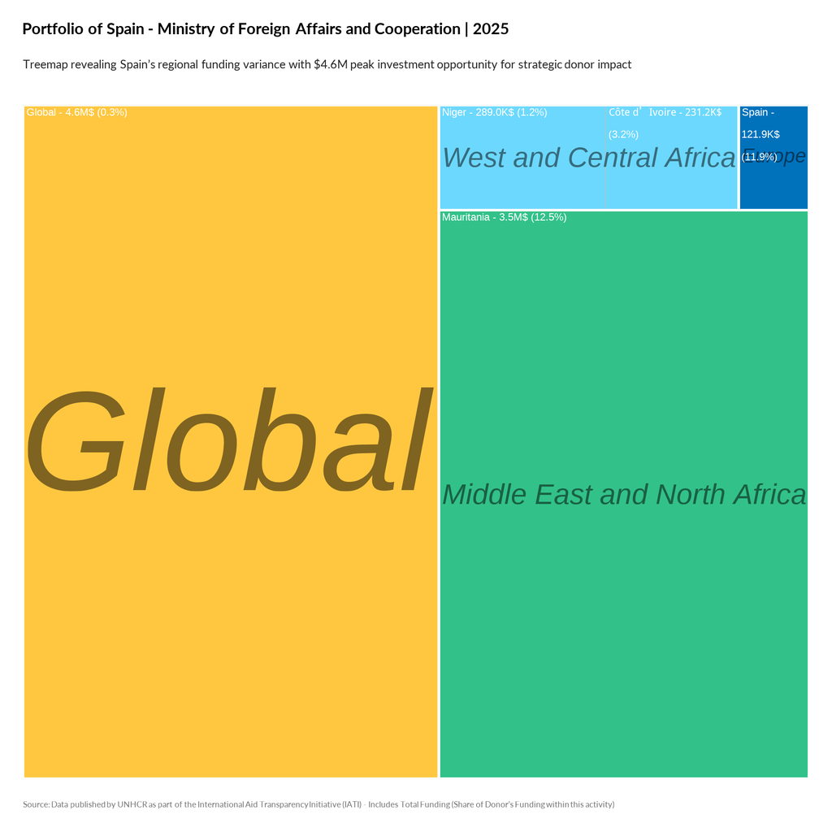

TRUE

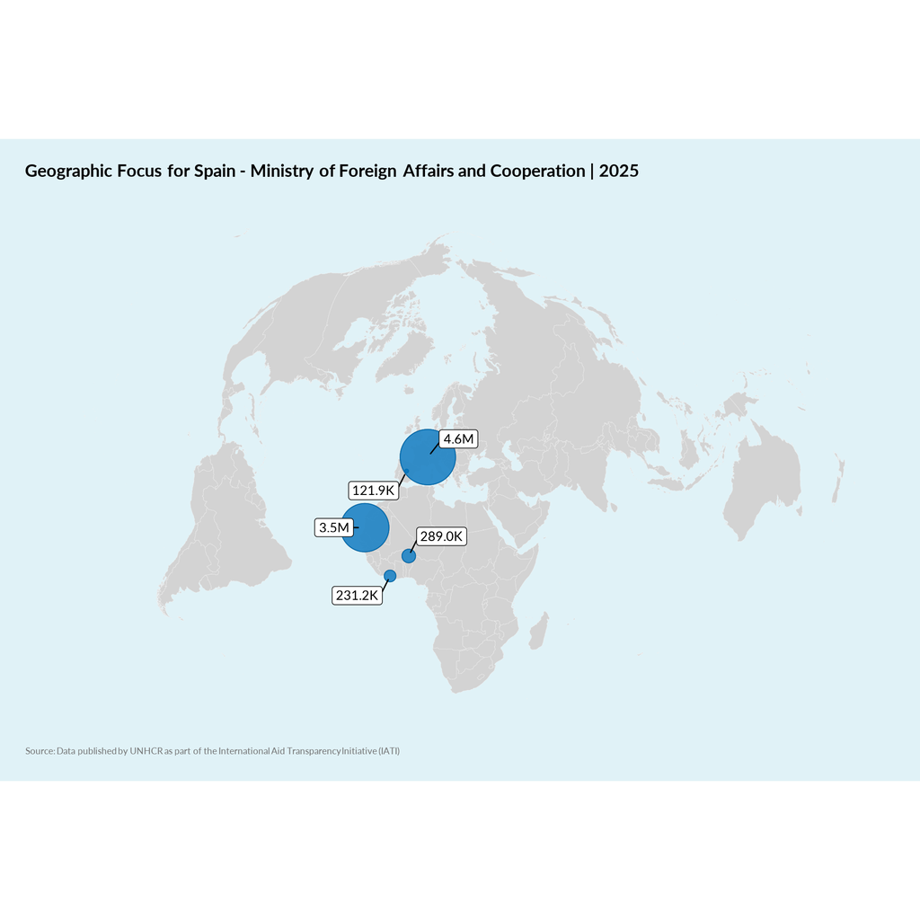

TRUE